## Use R to Analize data ‘savings’ from the **faraway** library

## Savings rates in 50 countries

The savings data frame has 50 rows and 5 columns. The data is averaged over the period 1960-1970. This data frame contains the following columns:

- sr – personal saving divided by disposable income
- pop15 – percent population under age of 15
- pop75 – percent population over age of 75
- dpi – per-capita disposable income in dollars
- ddpi – percent growth rate of dpi

```r
library(faraway)

fullmodel=lm(sr~pop15+pop75+dpi+ddpi, data=savings)
summary(fullmodel)
```

```
##
## Call:
## lm(formula = sr ~ pop15 + pop75 + dpi + ddpi, data = savings)
##
## Residuals:
##     Min      1Q  Median      3Q     Max
## -8.2422 -2.6857 -0.2488  2.4280  9.7509
##
## Coefficients:
##               Estimate Std. Error t value Pr(>|t|)
## (Intercept) 28.5660865  7.3545161   3.884 0.000334 ***
## pop15       -0.4611931  0.1446422  -3.189 0.002603 **
## pop75       -1.6914977  1.0835989  -1.561 0.125530
## dpi         -0.0003369  0.0009311  -0.362 0.719173
## ddpi         0.4096949  0.1961971   2.088 0.042471 *
## ---
## Signif. codes:  0 '***' 0.001 '**' 0.01 '*' 0.05 '.' 0.1 ' ' 1
##
## Residual standard error: 3.803 on 45 degrees of freedom
## Multiple R-squared:  0.3385, Adjusted R-squared:  0.2797
## F-statistic: 5.756 on 4 and 45 DF,  p-value: 0.0007904
```

## Compare two nested models via F-test

- Suppose our null hypothesis is H0: pop15 and pop75 are irrelevant to sr.

```r
reducedmodel=lm(sr~dpi+ddpi, data=savings)
summary(reducedmodel)
```

```
##
## Call:
## lm(formula = sr ~ dpi + ddpi, data = savings)
##
## Residuals:
##     Min      1Q  Median      3Q     Max
## -7.9650 -4.0397  0.8684  2.2491  9.3145
##
## Coefficients:
##              Estimate Std. Error t value Pr(>|t|)
## (Intercept) 6.3598478  1.2520610   5.080 6.43e-06 ***
## dpi         0.0011949  0.0006091   1.962   0.0557 .
## ddpi        0.5292495  0.2102883   2.517   0.0153 *
## ---
## Signif. codes:  0 '***' 0.001 '**' 0.01 '*' 0.05 '.' 0.1 ' ' 1
##
## Residual standard error: 4.189 on 47 degrees of freedom
## Multiple R-squared:  0.1616, Adjusted R-squared:  0.1259
## F-statistic: 4.528 on 2 and 47 DF,  p-value: 0.01591
```

```r
anova(reducedmodel, fullmodel)
```

```
## Analysis of Variance Table
##
## Model 1: sr ~ dpi + ddpi
## Model 2: sr ~ pop15 + pop75 + dpi + ddpi
##   Res.Df    RSS Df Sum of Sq      F   Pr(>F)
## 1     47 824.72
## 2     45 650.71  2       174 6.0167 0.004835 **
## ---
## Signif. codes:  0 '***' 0.001 '**' 0.01 '*' 0.05 '.' 0.1 ' ' 1
```

```r
#
rss.full=sum(fullmodel$res^2)
# rss.full=deviance(fullmodel) # you can use "deviance" to extract RSS
rss.reduced=sum(reducedmodel$res^2)
#rss.reduced = deviance(reducedmodel)
Fstat=(rss.reduced-rss.full)/2/(rss.full/45)
Fstat
```

```
## [1] 6.016652
```

```r
1-pf(Fstat, 2, 45)
```

```
## [1] 0.004834923
```

- Create a new variable which measures the percentage of the population between age 15 and 75, i.e., pop.mid = 1 - pop15 - pop75. Compare the following two models:

H0: sr ~ pop.mid + dpi + ddpi (model I)

Ha: sr ~ pop15 + pop75 + dpi + ddpi (model II)

Although model I seems to contain some new variable, pop.mid, it is contained in model II, in the sense that any linear combination of the three variables, as well as the intercept, in model I can be re-written as a linear combination of the four variables, as well as the intercept, in model II. On the other hand, not every linear combination of variables in model II can be written as a linear combination of variables in model I. That is, model II is larger than model I and contains model I as a special case.

```r
reducemodel=lm(sr ~ I(1-pop15-pop75) + dpi + ddpi, data=savings)
summary(reducemodel)
```

```
##
## Call:
## lm(formula = sr ~ I(1 - pop15 - pop75) + dpi + ddpi, data = savings)
##
## Residuals:
##    Min     1Q Median     3Q    Max
## -7.787 -2.767 -0.125  1.744 10.342
##
## Coefficients:
##                        Estimate Std. Error t value Pr(>|t|)
## (Intercept)          21.2756720  4.7824466   4.449 5.44e-05 ***
## I(1 - pop15 - pop75)  0.3336331  0.1038679   3.212  0.00241 **
## dpi                  -0.0008451  0.0008444  -1.001  0.32212
## ddpi                  0.3909649  0.1968714   1.986  0.05302 .
## ---
## Signif. codes:  0 '***' 0.001 '**' 0.01 '*' 0.05 '.' 0.1 ' ' 1
##
## Residual standard error: 3.827 on 46 degrees of freedom
## Multiple R-squared:  0.3152, Adjusted R-squared:  0.2705
## F-statistic: 7.056 on 3 and 46 DF,  p-value: 0.0005328
```

```r
anova(reducemodel, fullmodel)
```

```
## Analysis of Variance Table
##
## Model 1: sr ~ I(1 - pop15 - pop75) + dpi + ddpi
## Model 2: sr ~ pop15 + pop75 + dpi + ddpi
##   Res.Df    RSS Df Sum of Sq      F Pr(>F)
## 1     46 673.63
## 2     45 650.71  1    22.915 1.5847 0.2146
```

- We fail to reject H0, which indicates that the proposed variable is useful in explaining the variation in sr
- Suppose our null hypothesis is H0: pop15 is irrelevant. In this case, the partial F-test is equivalent to t-test.

```r
tmpmodel=lm(sr~pop75+dpi+ddpi,data=savings)
#summary(tmpmodel)
anova(tmpmodel, fullmodel)
```

```
## Analysis of Variance Table
##
## Model 1: sr ~ pop75 + dpi + ddpi
## Model 2: sr ~ pop15 + pop75 + dpi + ddpi
##   Res.Df    RSS Df Sum of Sq      F   Pr(>F)
## 1     46 797.72
## 2     45 650.71  1    147.01 10.167 0.002603 **
## ---
## Signif. codes:  0 '***' 0.001 '**' 0.01 '*' 0.05 '.' 0.1 ' ' 1
```

```r
summary(fullmodel)$coef
```

```
##                  Estimate   Std. Error    t value     Pr(>|t|)
## (Intercept) 28.5660865407 7.3545161062  3.8841558 0.0003338249
## pop15       -0.4611931471 0.1446422248 -3.1885098 0.0026030189
## pop75       -1.6914976767 1.0835989307 -1.5609998 0.1255297940
## dpi         -0.0003369019 0.0009311072 -0.3618293 0.7191731554
## ddpi         0.4096949279 0.1961971276  2.0881801 0.0424711387
```

```r
summary(fullmodel)$coef[2,3]^2  # t-stat^2 = F-stat
```

```
## [1] 10.16659
```

## LS Coefficient

The LS coefficient beta_j describes the partial correlation between Y and X_j adjusted for the other predictors.

beta_j from MLR can be estimated via the following steps:

1. regress Y onto all other predictors except X_j;
2. regress X_j onto all other predictors except X_j;
3. regress the residual from (1) onto the residual from (2).

```r
new.y=lm(sr~pop15+pop75+dpi, data=savings)$res
new.ddpi = lm(ddpi~pop15+pop75+dpi, data=savings)$res
parmodel=lm(new.y ~ new.ddpi)
parmodel$coef
```

```
##   (Intercept)      new.ddpi
## -4.388648e-17  4.096949e-01
```

```r
fullmodel$coef
```

```
##   (Intercept)         pop15         pop75           dpi          ddpi
## 28.5660865407 -0.4611931471 -1.6914976767 -0.0003369019  0.4096949279
```

## Permutation Test

When the normal assumption is questionable, we can use a permutation test.

Suppose our null hypothesis is H0: sr ~ dpi + ddpi and Ha: sr ~ pop15 + pop75 + dpi + ddpi.

Let’s use F-stat from the full model as the test statistic: If pop15 and pop75 are indeed relevant to sr, we would expect the F-stat to be large. So large F-stat (from the full model) supports Ha (i.e., we know the rejection region).

Now the goal is to find the distribution of the F-stat under the null hypothesis (without using any normal assumption). How can we get a data set, which also involves 50 countries with all the four variables, and which looks like a data set from H0?

Recall that under H0, pop15 and pop75 are irrelevant. In our data, we have 50 pairs of (pop15, pop75), each corresponding to a county. What if we randomly assign a pair of (pop15, pop75) associated with one country to another country (repeat this for all 50 pairs), and then re-fit the full model? The inference based on this new data set shouldn’t be affected that much, if (pop15, pop75) is truly irrelevant to sr. This is the idea behind the permutation test.

```r
n.iter = 2000;
fstats = numeric(n.iter);
for(i in 1:n.iter){
   newsavings=savings;
    newsavings[,c(2,3)]=savings[sample(50),c(2,3)];
    ge = lm(sr ~., data=newsavings);
    fstats[i] = summary(ge)$fstat[1]
}
length(fstats[fstats > summary(fullmodel)$fstat[1]])/n.iter
```

```
## [1] 0.0055
```

```r
sample(1:5)
```

```
## [1] 4 3 2 5 1
```

```r
sample(1:5)
```

```
## [1] 3 1 4 2 5
```

## Confidence/Prediction Interval, Confidence Region

Use the command “confint” to obtain confidence intervals for regression coefficients.

```r
confint(fullmodel)
```

```
##                    2.5 %       97.5 %
## (Intercept) 13.753330728 43.378842354
## pop15       -0.752517542 -0.169868752
## pop75       -3.873977955  0.490982602
## dpi         -0.002212248  0.001538444
## ddpi         0.014533628  0.804856227
```

```r
confint(fullmodel, 'pop15', level=0.99)
```

```
##            0.5 %      99.5 %
## pop15 -0.8502207 -0.07216559
```

Use the command “ellipse” from the ellipse package to obtain confidence regions. Here we plot the confidence region for (pop15, pop75), which is an ellipsoid centered at the LS estimate of their coefficients.

Recall that we tested whether their LS coefficients are zero using the F-test earlier. Now, using the duality of Confidence region/interval and hypothesis test, we reject the hypothesis based on whether the point (0,0) is inside the ellipsoid or not.

```r
library(ellipse)
```

```r
library(ggplot2)

CR95 = ellipse(fullmodel, c(2,3))
CR99 = ellipse(fullmodel, c(2,3), level=0.99)
CR998 = ellipse(fullmodel, c(2,3), level=0.998)
dim(CR95)
```

```
## [1] 100   2
```

```r
head(CR95)
```

```
##           pop15     pop75
## [1,] -0.1171769 0.8857281
## [2,] -0.1258241 0.9401321
## [3,] -0.1358218 0.9839396
## [4,] -0.1471296 1.0169740
## [5,] -0.1597021 1.0391023
## [6,] -0.1734885 1.0502354
```

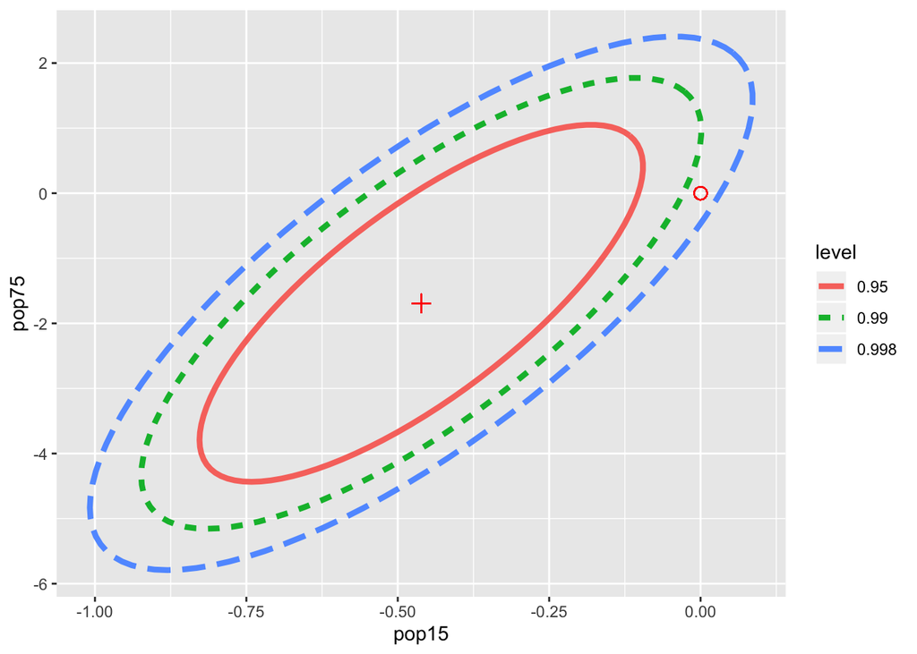

```r
myCR = rbind(CR95, CR99, CR998);
myCR = data.frame(myCR);
names(myCR) = c("pop15","pop75");
myCR[, 'level']=as.factor(c(rep(0.95, dim(CR95)[1]),
                              rep(0.99, dim(CR99)[1]),
                              rep(0.998, dim(CR998)[1])));


ggplot(data=myCR, aes(x=pop15, y=pop75, colour=level)) +
  geom_path(aes(linetype=level), size=1.5) +
  geom_point(x=coef(fullmodel)[2], y=coef(fullmodel)[3], shape=3, size=3, colour='red') +
  geom_point(x=0, y=0, shape=1, size=3, colour='red')
```

Let’s find the 95 percent confidence interval (CI) and prediction interval (PI) at the mean value of the predictors.

```r
# create a data frame on which you’d like to predict
meanvalue=apply(savings[,2:5],2,mean)
meanvalue
```

```
##     pop15     pop75       dpi      ddpi
##   35.0896    2.2930 1106.7584    3.7576
```

```r
x=data.frame(t(meanvalue))
predict.lm(fullmodel,x,interval="confidence")
```

```
##     fit      lwr      upr
## 1 9.671 8.587858 10.75414
```

```r
predict.lm(fullmodel,x,interval="prediction")
```

```
##     fit      lwr      upr
## 1 9.671 1.935822 17.40618
```

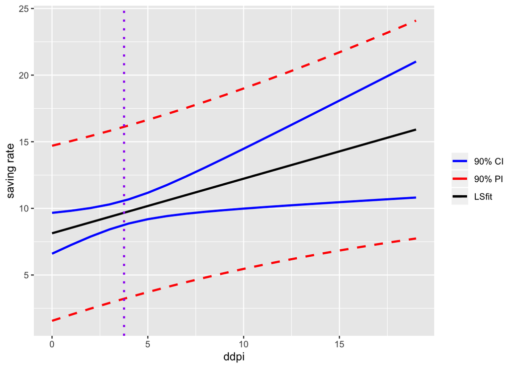

```r
# First create the data frame on which you need to predict
# range(savings$ddpi)
#[1]  0.22 16.71
x=matrix(meanvalue[1:3], 20, 3, byrow=TRUE)
colnames(x)=c("pop15", "pop75", "dpi")
x=data.frame(x)
# head(x)
x[, 'ddpi']=0:19;
# head(x)

myCI=predict.lm(fullmodel,x,interval="confidence", level=0.90);
myPI=predict.lm(fullmodel,x,interval="prediction", level=0.90);


# Form the data frame for plotting
ggplot(data=NULL, aes(x=0:19)) +
  geom_line(aes(y=myCI[,1], colour="LSfit"), size=1) +
  geom_line(aes(y=myCI[,2], colour="90% CI"), size=1) +
  geom_line(aes(y=myCI[,3], colour="90% CI"), size=1) +
  geom_line(aes(y=myPI[,2], colour="90% PI"), size=1, linetype=2) +
  geom_line(aes(y=myPI[,3], colour="90% PI"), size=1, linetype=2) +
  scale_colour_manual("", values=c("LSfit" = "black",
                               "90% CI" = "blue",
                               "90% PI"="red")) +
  xlab("ddpi") +ylab("saving rate") +
  geom_vline(xintercept = mean(savings$ddpi), colour="purple", size=1, linetype=3)
```